# Alzheimer’s Analysis

Abdullah Choudhry & Matthew Kunkel

2025-03-07

# **Introduction**

## **Dataset Link**

https://www.kaggle.com/datasets/ankushpanday1/alzheimers-prediction-dataset-global

## **Dataset Description**

### **Features in the Dataset:**

- **Demographic Factors**
  - `Country`: Country of residence
  - `Age`: Age of the individual
  - `Gender`: Male/Female
- **Lifestyle & Health Factors**
  - `Education Level`: Years of education
  - `BMI`: Body Mass Index
  - `Physical Activity Level`: Frequency of physical activity
  - `Smoking Status`: Non-smoker, Former smoker, Current smoker
  - `Alcohol Consumption`: Frequency of alcohol intake
  - `Diabetes`: Presence of diabetes (Yes/No)
  - `Hypertension`: Presence of high blood pressure (Yes/No)
  - `Cholesterol Level`: Cholesterol status
- **Cognitive & Psychological Factors**
  - `Family History of Alzheimer’s`: Whether a family member had Alzheimer’s
  - `Cognitive Test Score`: A numerical cognitive ability assessment
  - `Depression Level`: Scale of depressive symptoms
  - `Sleep Quality`: Rating of sleep patterns
- **Environmental & Social Factors**
  - `Dietary Habits`: Nutritional quality of diet
  - `Air Pollution Exposure`: Level of exposure to pollutants
  - `Employment Status`: Employed, Unemployed, Retired
  - `Marital Status`: Single, Married, Divorced, Widowed
  - `Genetic Risk Factor (APOE-ε4 allele)`: Presence of high-risk allele
  - `Social Engagement Level`: Interaction frequency with social networks
  - `Income Level`: Income category
  - `Stress Levels`: Self-reported stress level
  - `Urban vs Rural Living`: Living in urban vs rural areas
- **Target Variable**
  - `Alzheimers Diagnosis`: Whether the individual is diagnosed with Alzheimer’s

Each observation represents an individual and their corresponding health and lifestyle data.

## **Motivation**

Alzheimer’s disease is a **progressive neurological disorder** that affects memory and cognitive functions. Early diagnosis and intervention can **improve quality of life** and **reduce healthcare burdens**.

This topic motivates us because **understanding the key factors behind cognitive decline** can help improve **early detection methods and prevention strategies**. By analyzing this dataset, we hope to **gain insights that could contribute to better screening practices** and help individuals at risk for Alzheimer’s. The opportunity to work with real-world health data allows us to **apply data science techniques to an important medical challenge**, making our work both meaningful and impactful.

## **Loading the Dataset**

```r
# Load library
library(tidyverse)
# Read the dataset
df <- read_csv("alzheimers_prediction_dataset.csv")
# Summary Statistics
summary(df)
```

```
##    Country               Age           Gender          Education Level
##  Length:74283       Min.   :50.00   Length:74283       Min.   : 0.000
##  Class :character   1st Qu.:61.00   Class :character   1st Qu.: 4.000
##  Mode  :character   Median :72.00   Mode  :character   Median : 9.000
##                     Mean   :71.96                      Mean   : 9.488
##                     3rd Qu.:83.00                      3rd Qu.:14.000
##                     Max.   :94.00                      Max.   :19.000
##       BMI        Physical Activity Level Smoking Status     Alcohol Consumption
##  Min.   :18.50   Length:74283            Length:74283       Length:74283
##  1st Qu.:22.70   Class :character        Class :character   Class :character
##  Median :26.80   Mode  :character        Mode  :character   Mode  :character
##  Mean   :26.78
##  3rd Qu.:30.90
##  Max.   :35.00
##    Diabetes         Hypertension       Cholesterol Level
##  Length:74283       Length:74283       Length:74283
##  Class :character   Class :character   Class :character
##  Mode  :character   Mode  :character   Mode  :character
##
##
##
##  Family History of Alzheimer’s Cognitive Test Score Depression Level
##  Length:74283                  Min.   :30.00        Length:74283
##  Class :character              1st Qu.:47.00        Class :character
##  Mode  :character              Median :65.00        Mode  :character
##                                Mean   :64.65
##                                3rd Qu.:82.00
##                                Max.   :99.00
##  Sleep Quality      Dietary Habits     Air Pollution Exposure
##  Length:74283       Length:74283       Length:74283
##  Class :character   Class :character   Class :character
##  Mode  :character   Mode  :character   Mode  :character
##
##
##
##  Employment Status  Marital Status     Genetic Risk Factor (APOE-ε4 allele)
##  Length:74283       Length:74283       Length:74283
##  Class :character   Class :character   Class :character
##  Mode  :character   Mode  :character   Mode  :character
##
##
##
##  Social Engagement Level Income Level       Stress Levels
##  Length:74283            Length:74283       Length:74283
##  Class :character        Class :character   Class :character
##  Mode  :character        Mode  :character   Mode  :character
##
##
##
##  Urban vs Rural Living Alzheimer’s Diagnosis
##  Length:74283          Length:74283
##  Class :character      Class :character
##  Mode  :character      Mode  :character
##
##
##
```

# **Visualization**

## **1. Density Map: Cognitive Test Score vs. Age (By Alzheimer’s Diagnosis)**

We examine how **cognitive test scores** vary with **age**, comparing individuals **with and without Alzheimer’s**.

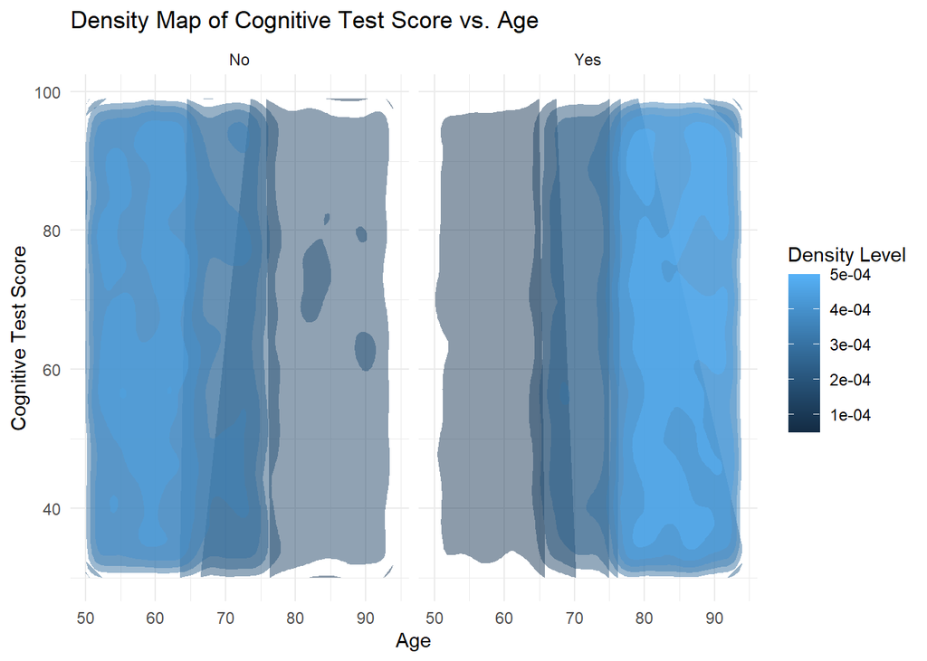

```r
# Density map: Age vs. Cognitive Test Score, faceted by Alzheimer's Diagnosis
ggplot(df, aes(x = Age, y = `Cognitive Test Score`)) +
  stat_density_2d(aes(fill = after_stat(level)), geom = "polygon", alpha = 0.5) +
  facet_wrap(~ `Alzheimer’s Diagnosis`) +
  labs(
    title = "Density Map of Cognitive Test Score vs. Age",
    x = "Age",
    y = "Cognitive Test Score",
    fill = "Density Level"
  ) +
  theme_minimal()
```

# **2. Boxplot: Education Levels vs. Alzheimer’s Diagnosis (By Country)**

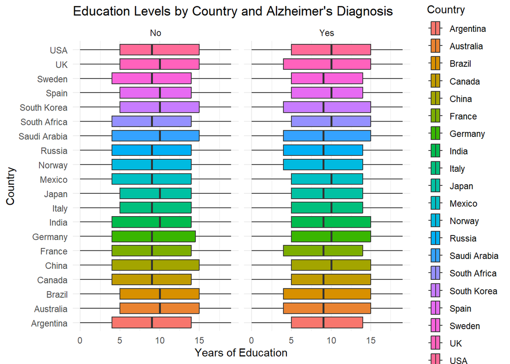

```r
# Boxplot: Education Level vs. Country, faceted by Alzheimer's Diagnosis
ggplot(df, aes(x = `Education Level`, y = Country, fill = Country)) +
  geom_boxplot() +
  facet_wrap(~ `Alzheimer’s Diagnosis`) +
  labs(
    title = "Education Levels by Country and Alzheimer's Diagnosis",
    x = "Years of Education",
    y = "Country",
    fill = "Country"
  ) +
  theme_minimal()
```

# **Dataset Manipulations**

## **How Data Manipulation Reveals New Insights**

One way to uncover meaningful patterns in our dataset is by **categorizing individuals into different age groups** and examining how **education levels vary within each group**.

We then visualize **how education levels differ across these age groups**, separately for **Alzheimer’s and non-Alzheimer’s individuals**.

By structuring the data in this way, we gain new insights into:

How education levels have changed over time across different age groups. Whether lower education is associated with a higher likelihood of Alzheimer’s, particularly in older adults. Potential protective effects of education in delaying cognitive decline. This manipulation helps us go beyond raw numbers and visually assess how education and age interact with Alzheimer’s diagnosis, uncovering relationships that might not be obvious in the unprocessed dataset.

Data manipulations allow us to restructure and summarize complex datasets, making it easier to spot hidden relationships and trends. Instead of analyzing raw values, we can group, filter, or transform data to highlight meaningful differences between subgroups. In this case, breaking down education levels by age and diagnosis helps us understand whether education plays a role in Alzheimer’s risk, which might not be immediately visible without categorization.

## **Education Level vs. Age Group (By Alzheimer’s Diagnosis)**

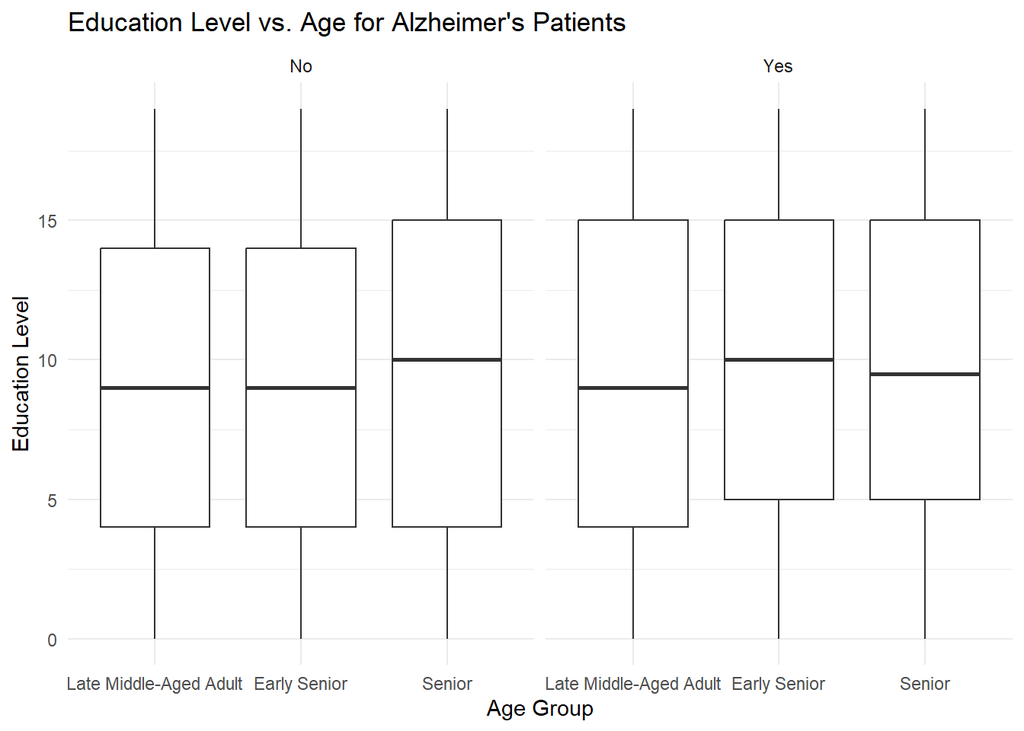

```r
# Create Age Groups with Updated Labels
df <- df %>%
  mutate(Age_Group = cut(Age, breaks = c(49, 62, 83, 95, Inf),
                         labels = c("Late Middle-Aged Adult", "Early Senior", "Senior", "Elderly")))

# Boxplot: Education Level vs. Age Group, faceted by Alzheimer's Diagnosis
ggplot(df, aes(Age_Group, `Education Level`)) +
  geom_boxplot() +
  labs(
    title = "Education Level vs. Age for Alzheimer's Patients",
    x = "Age Group",
    y = "Education Level"
  ) +
  facet_wrap(~ `Alzheimer’s Diagnosis`) +
  theme_minimal()
```

# **Statistical Analyses**

## **1. Correlation Analysis: BMI vs. Cognitive Test Score**

To examine whether **Body Mass Index (BMI) is associated with cognitive performance**, we compute a **Spearman correlation** between **BMI and Cognitive Test Score**.

```r
# Compute Spearman correlation
cor.test(df$BMI, df$`Cognitive Test Score`, method = "spearman")
```

```
##
##  Spearman's rank correlation rho
##
## data:  df$BMI and df$`Cognitive Test Score`
## S = 6.7937e+13, p-value = 0.131
## alternative hypothesis: true rho is not equal to 0
## sample estimates:
##         rho
## 0.005541323
```

## **Interpretation:**

- The **Spearman correlation coefficient (rho) is 0.0055**, indicating an **extremely weak positive relationship** between **BMI and Cognitive Test Score**. This means that changes in **BMI have almost no effect on cognitive test scores** in this dataset.
- The **p-value is 0.131**, which is **greater than 0.05**, meaning this correlation **is not statistically significant**. Therefore, we **fail to reject the null hypothesis**, indicating that **BMI is not meaningfully associated with cognitive performance** in this dataset.
- Since the correlation is **so close to zero**, these results suggest that **BMI is not a predictor of cognitive function** within this population.

## **2. Linear Regression: Age vs. Cognitive Test Score**

To assess how age influences cognitive test scores, we perform a linear regression.

```r
# Perform linear regression
model <- lm(`Cognitive Test Score` ~ Age, data = df)
summary(model)
```

```
##
## Call:
## lm(formula = `Cognitive Test Score` ~ Age, data = df)
##
## Residuals:
##     Min      1Q  Median      3Q     Max
## -34.656 -17.653   0.345  17.346  34.347
##
## Coefficients:
##              Estimate Std. Error t value Pr(>|t|)
## (Intercept) 6.465e+01  4.166e-01 155.196   <2e-16 ***
## Age         7.673e-05  5.696e-03   0.013    0.989
## ---
## Signif. codes:  0 '***' 0.001 '**' 0.01 '*' 0.05 '.' 0.1 ' ' 1
##
## Residual standard error: 20.15 on 74281 degrees of freedom
## Multiple R-squared:  2.443e-09,  Adjusted R-squared:  -1.346e-05
## F-statistic: 0.0001814 on 1 and 74281 DF,  p-value: 0.9893
```

## **Interpretation:**

- The **slope coefficient for Age is 7.67e-05**, meaning that **cognitive test scores increase by an extremely small amount (essentially zero) per year of age**. This contradicts the expected trend of cognitive decline with age.
- The **p-value for Age is 0.989**, which is **much greater than 0.05**, meaning that **Age is not a statistically significant predictor** of cognitive test scores in this dataset.
- The **R-squared value is 2.443e-09 (~0)**, meaning that **Age explains almost none (0%) of the variation in cognitive test scores**. This suggests that **other factors, not Age, contribute to differences in cognitive test scores**.
- Given the **lack of statistical significance and near-zero explanatory power**, these results indicate that **age has no meaningful effect on cognitive test scores in this dataset**.

## **3. T-Test: Age vs. Alzheimer’s Diagnosis**

We use a t-test to compare the mean age of individuals with and without Alzheimer’s.

```r
# Perform t-test
t.test(Age ~ `Alzheimer’s Diagnosis`, data = df)
```

```
##
##  Welch Two Sample t-test
##
## data:  Age by Alzheimer’s Diagnosis
## t = -128.02, df = 69425, p-value < 2.2e-16
## alternative hypothesis: true difference in means between group No and group Yes is not equal to 0
## 95 percent confidence interval:
##  -11.23827 -10.89934
## sample estimates:
##  mean in group No mean in group Yes
##          67.38820          78.45701
```

## **Interpretation:**

- The **mean age of individuals without Alzheimer’s is 67.39 years**, while the **mean age of individuals with Alzheimer’s is 78.46 years**. This shows that **the diagnosed group is, on average, 11 years older than the non-diagnosed group**.
- The **t-test statistic is -128.02**, and the **p-value is <2.2e-16**, which is **extremely small** and **far below 0.05**. This means the **difference in mean age between the two groups is highly statistically significant**.
- The **95% confidence interval (-11.238, -10.899)** does **not** include zero, confirming that the difference in mean age is **real and not due to random variation**.
- These results strongly support the conclusion that **age is a major factor in Alzheimer’s diagnosis**, with individuals diagnosed with Alzheimer’s being **significantly older than those without the disease**.

## **How Can You Use This Dataset to Draw Conclusions About a Larger Population?**

These statistical tests help us identify **patterns within the dataset** that can be generalized to a larger population.

- The **correlation analysis** shows that **BMI is not strongly linked to cognitive test scores**, suggesting that **BMI alone is not a reliable predictor of cognitive function**.
- The linear regression analysis **does not find a significant relationship** between age and cognitive test scores, suggesting that age alone **may not be a strong predictor of cognitive function in this dataset**.
- However, the t-test analysis reveals that individuals diagnosed with Alzheimer’s are significantly older on average, reinforcing that age plays a major role in Alzheimer’s prevalence.

Since this dataset contains a **large number of observations (74,283 records)** across **various demographic and health factors**, these trends can be used to make broader inferences. By analyzing these relationships, we can use this dataset to **support larger-scale studies** and **inform public health decisions** regarding cognitive health and Alzheimer’s risk factors.

# **Conclusion**

Our analysis of this dataset has revealed key insights into **Alzheimer’s risk factors** and **cognitive decline**:

### **Key Takeaways**

- **Age is a strong predictor of Alzheimer’s diagnosis but not of cognitive test scores.**
- **Other factors beyond BMI, age, and education should be explored** to determine additional contributors to cognitive decline.
- **Data-driven approaches can provide valuable insights**, but further research is needed to confirm causal relationships and identify additional risk factors for cognitive decline and Alzheimer’s.